# task5

```python
import pandas as pd

# Load the dataset
df = pd.read_csv('ecommerce_sales_data.csv')

# Inspect the first few rows of the dataset
df.head()
```

|  | Order ID | Product Name | Category | Price | Quantity | Total Sales | Customer ID | Customer Age | Customer Gender | Purchase Date | Purchase Time |
| --- | --- | --- | --- | --- | --- | --- | --- | --- | --- | --- | --- |
| 0 | 261e3740-c0e9-42b1-bf87-881ac950fa3a | audience | Home & Garden | 766.85 | 4 | 3067.40 | 81af1248-afff-46ee-a091-81cf33d0d957 | 39 | Male | 25/05/2024 | 6:28:14 |
| 1 | 0b332b34-46dc-4eaf-a808-fec7e97ffbc6 | such | Clothing | 331.42 | 4 | 1325.68 | f3f3f4ac-7ad0-4362-9134-383096d16ac8 | 21 | Male | 04/05/2024 | 19:37:36 |
| 2 | 432e0b36-724d-4521-85ae-f66db8af8105 | read | Clothing | 708.10 | 10 | 7081.00 | c4fc4269-3c1d-4b6b-ad23-d437c328d63f | 27 | Female | 07/05/2024 | 17:54:42 |
| 3 | ca20fb08-5c65-43b8-9577-3fa49913f93b | skill | Electronics | 774.09 | 2 | 1548.18 | 578e2d1a-d92a-449d-8eeb-b704110b2975 | 51 | Female | 23/05/2024 | 22:31:43 |
| 4 | 1dce189c-8c60-455f-a6f2-69bb2cb71539 | cold | Electronics | 397.22 | 1 | 397.22 | dc6ed196-0874-46bd-bbb9-c5534f619349 | 45 | Female | 15/03/2024 | 3:08:25 |

```python
# Simple Moving Average (SMA)
df['SMA_7'] = df['Total Sales'].rolling(window=7).mean()  # 7-day moving average
```

```python
#Exponential Smoothing (Holt-Winters)
from statsmodels.tsa.holtwinters import ExponentialSmoothing
model = ExponentialSmoothing(df['Total Sales'], trend='add', seasonal='add', seasonal_periods=12)
model_fit = model.fit()
forecast = model_fit.forecast(steps=12)  # Forecast for 12 months
```

```python
from statsmodels.tsa.arima.model import ARIMA
model = ARIMA(df['Total Sales'], order=(5,1,0))  # Adjust (p, d, q) for optimal model
model_fit = model.fit()
forecast = model_fit.forecast(steps=12)  # Forecast for the next 12 periods
```

```python
from prophet import Prophet
```

```python
print(df.columns)
```

```
Index(['Order ID', 'Product Name', 'Category', 'Price', 'Quantity',
       'Total Sales', 'Customer ID', 'Customer Age', 'Customer Gender',
       'Purchase Date', 'Purchase Time', 'SMA_7'],
      dtype='object')
```

Ensure no duplicate or conflicting periods argument:

The make_future_dataframe method should only receive periods as a keyword argument, not as a positional argument.

Make sure that you are not accidentally passing periods through other variables.

Check DataFrame before fitting:

The DataFrame (df_prophet) should have only the columns ds and y after renaming, and the ds column should be in datetime format.

Make sure no additional periods variables are set in your code or passed anywhere else.

```python
!pip show prophet
```

```
Name: prophet
Version: 1.1.6
Summary: Automatic Forecasting Procedure
Home-page: https://facebook.github.io/prophet/
Author:
Author-email: "Sean J. Taylor" <sjtz@pm.me>, Ben Letham <bletham@fb.com>
License: MIT
Location: C:\Users\LENOVO\AppData\Local\Programs\Python\Python313\Lib\site-packages
Requires: cmdstanpy, holidays, importlib-resources, matplotlib, numpy, pandas, tqdm
Required-by:
```

Prepare your data: Ensure the dataset contains the necessary columns: ds (date) and y (the value you want to forecast, e.g., total sales).

Account for seasonality: Prophet automatically handles daily, weekly, and yearly seasonality. You can also add custom seasonal effects (like Diwali sales).

Fit the model: Use the Prophet class to train the model.

Forecast future values: Predict future values using the make_future_dataframe() method

```python
from prophet import Prophet
import pandas as pd

# Example dataset based on your e-commerce sales data
df = pd.DataFrame({
    'Order ID': ['1', '2', '3'],
    'Product Name': ['Product A', 'Product B', 'Product C'],
    'Category': ['Category X', 'Category Y', 'Category Z'],
    'Price': [100, 200, 150],
    'Quantity': [1, 2, 3],
    'Total Sales': [100, 400, 450],  # Target for forecasting
    'Customer ID': ['cust1', 'cust2', 'cust3'],
    'Customer Age': [25, 30, 35],
    'Customer Gender': ['Male', 'Female', 'Male'],
    'Purchase Date': ['2024-01-01', '2024-01-02', '2024-01-03'],  # Dates for 'ds'
    'Purchase Time': ['10:00', '12:00', '14:00'],
    'SMA_7': [95, 105, 110]  # Example additional column
})

# Step 1: Prepare the dataset
# Rename columns to 'ds' and 'y' for Prophet
df_prophet = df.rename(columns={'Purchase Date': 'ds', 'Total Sales': 'y'})

# Step 2: Ensure that 'ds' is in datetime format
df_prophet['ds'] = pd.to_datetime(df_prophet['ds'], errors='coerce')

# Step 3: Drop rows with missing values
df_prophet = df_prophet.dropna(subset=['ds', 'y'])

# Step 4: Visualize the first few rows
print(df_prophet.head())  # Ensure 'ds' and 'y' are correctly formatted

# Step 5: Initialize Prophet model
model = Prophet(yearly_seasonality=True, daily_seasonality=False)

# Adding custom seasonal effects (e.g., Diwali sales) can be done here:
# model.add_seasonality(name='diwali', period=365, fourier_order=5)

# Step 6: Fit the model
model.fit(df_prophet)

# Step 7: Create future dataframe for 12 months (or customize frequency as needed)
future = model.make_future_dataframe(df_prophet, periods=365, freq='D')  # Daily forecast for 1 year

# Step 8: Forecast future values
forecast = model.predict(future)

# Step 9: Visualize the forecast
model.plot(forecast)

# Step 10: Visualize forecast components (trends, yearly seasonality, etc.)
model.plot_components(forecast)
```

```
  Order ID Product Name    Category  Price  Quantity    y Customer ID  \
0        1    Product A  Category X    100         1  100       cust1
1        2    Product B  Category Y    200         2  400       cust2
2        3    Product C  Category Z    150         3  450       cust3

   Customer Age Customer Gender         ds Purchase Time  SMA_7
0            25            Male 2024-01-01         10:00     95
1            30          Female 2024-01-02         12:00    105
2            35            Male 2024-01-03         14:00    110
```

```
10:16:03 - cmdstanpy - INFO - Chain [1] start processing
10:16:04 - cmdstanpy - INFO - Chain [1] done processing
```

[output not shown]

Dataset Preparation:

The dataset should have a date column (named ds) and a column with the target values (named y).

Ensure the date column is in datetime format for Prophet to process it correctly.

Handling Seasonality:

Prophet automatically accounts for yearly and weekly seasonality. If you have special events like Diwali, you can add a custom seasonal effect using add_seasonality(). For example, the Diwali sales might have a yearly effect that you can model by specifying the period and fourier order.

Forecasting:

make_future_dataframe() generates a DataFrame for future predictions. The periods argument specifies the number of periods (e.g., days) you want to predict. For example, periods=365 predicts one year of data (if you are forecasting daily sales).

freq='D' specifies that the predictions are daily. You can change this to M for monthly predictions or H for hourly predictions based on your needs.

Visualization:

model.plot(forecast) will visualize the forecast.

model.plot_components(forecast) will show the trend, seasonality, and holidays (if any).

```python
from prophet import Prophet
import pandas as pd

# Example dataset based on your e-commerce sales data
data = {
    'Order ID': ['1', '2', '3', '4', '5', '6', '7', '8', '9', '10'],
    'Product Name': ['Product A', 'Product B', 'Product C', 'Product A', 'Product B', 'Product C', 'Product A', 'Product B', 'Product C', 'Product A'],
    'Category': ['Category X', 'Category Y', 'Category Z', 'Category X', 'Category Y', 'Category Z', 'Category X', 'Category Y', 'Category Z', 'Category X'],
    'Price': [100, 200, 150, 100, 200, 150, 100, 200, 150, 100],
    'Quantity': [1, 2, 3, 1, 2, 3, 1, 2, 3, 1],
    'Total Sales': [100, 400, 450, 110, 420, 470, 120, 440, 490, 500],  # Target for forecasting
    'Customer ID': ['cust1', 'cust2', 'cust3', 'cust1', 'cust2', 'cust3', 'cust1', 'cust2', 'cust3', 'cust4'],
    'Customer Age': [25, 30, 35, 25, 30, 35, 25, 30, 35, 40],
    'Customer Gender': ['Male', 'Female', 'Male', 'Male', 'Female', 'Male', 'Male', 'Female', 'Male', 'Female'],
    'Purchase Date': ['2024-01-01', '2024-01-02', '2024-01-03', '2024-01-04', '2024-01-05', '2024-01-06', '2024-01-07', '2024-01-08', '2024-01-09', '2024-01-10'],  # Dates for 'ds'
    'Purchase Time': ['10:00', '12:00', '14:00', '10:00', '12:00', '14:00', '10:00', '12:00', '14:00', '15:00'],
    'SMA_7': [95, 105, 110, 100, 115, 120, 105, 120, 125, 130]  # Example additional column
}
df = pd.DataFrame(data)

# Step 1: Prepare the dataset
# Rename columns to 'ds' and 'y' for Prophet
df_prophet = df.rename(columns={'Purchase Date': 'ds', 'Total Sales': 'y'})

# Step 2: Ensure that 'ds' is in datetime format
df_prophet['ds'] = pd.to_datetime(df_prophet['ds'], errors='coerce')

# Step 3: Drop rows with missing values
df_prophet = df_prophet.dropna(subset=['ds', 'y'])

# Step 4: Visualize the first few rows
print(df_prophet.head())  # Ensure 'ds' and 'y' are correctly formatted

# Step 5: Initialize Prophet model
model = Prophet(yearly_seasonality=True, daily_seasonality=False)

# **Add custom seasonal effects before fitting the model**
# Example: Diwali seasonality (assuming a yearly cycle, period=365 days)
model.add_seasonality(name='diwali', period=365, fourier_order=5)

# Step 6: Fit the model
model.fit(df_prophet)

# Step 7: Create future dataframe for 12 months (or customize frequency as needed)
future = model.make_future_dataframe(periods=365, freq='D')  # Daily forecast for 1 year

# Step 8: Forecast future values
forecast = model.predict(future)

# Step 9: Visualize the forecast
forecast_plot = model.plot(forecast) # Store the plot object

# Step 10: Visualize forecast components (trends, yearly seasonality, etc.)
forecast_components_plot = model.plot_components(forecast) # Store the plot object

# Display the plots (optional, if running in a script)
import matplotlib.pyplot as plt
plt.show()
```

[output not shown]

Key Steps: Data Preprocessing: Prepare the dataset (normalize, reshape, etc.).

LSTM Model Construction: Build and compile the LSTM model.

Model Training: Fit the model on the training data.

Prediction: Make predictions for future sales.

```python
import sys
print(sys.executable)
```

```python
import platform
print(platform.architecture())
# Exit Python by typing exit() or Ctrl+Z/Ctrl+D
```

```python
pip install tensorflow
```

```
Simple Moving Average — MAE: 69224.65, RMSE: 83220.48
Holt-Winters — MAE: 66728.69, RMSE: 81611.75
```

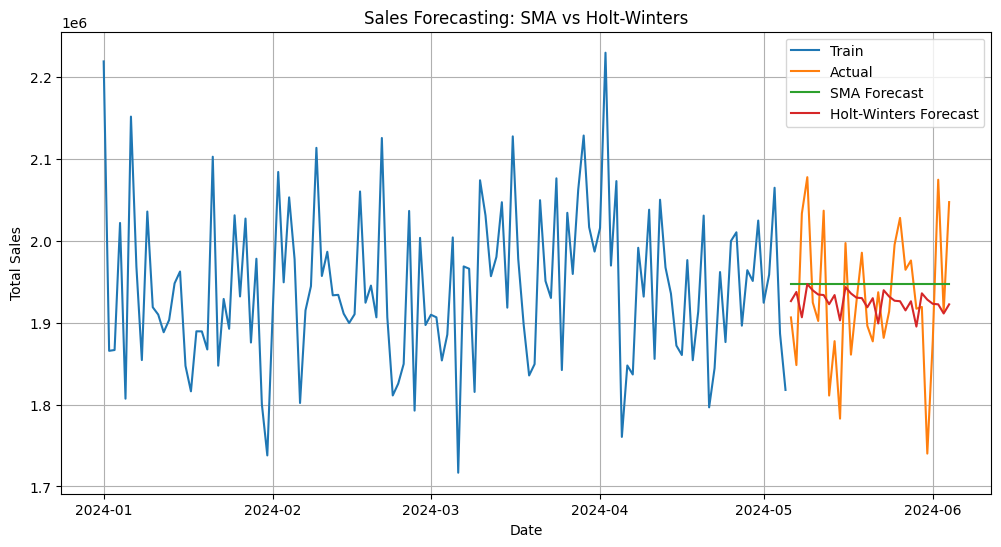

```python
import pandas as pd
import matplotlib.pyplot as plt
from statsmodels.tsa.holtwinters import ExponentialSmoothing
from sklearn.metrics import mean_absolute_error, mean_squared_error
import numpy as np

# Step 1: Load and preprocess data
df = pd.read_csv('ecommerce_sales_data.csv')

# Convert 'Purchase Date' to datetime and aggregate total sales by date
df['Purchase Date'] = pd.to_datetime(df['Purchase Date'])
df_daily = df.groupby('Purchase Date')['Total Sales'].sum().reset_index()
df_daily = df_daily.sort_values('Purchase Date')
df_daily.set_index('Purchase Date', inplace=True)

# Split into train and test (e.g., last 30 days for testing)
train = df_daily.iloc[:-30]
test = df_daily.iloc[-30:]

# Step 2: Moving Average Forecast
sma_forecast = train['Total Sales'].rolling(window=7).mean().iloc[-1]
sma_preds = [sma_forecast] * len(test)

# Step 3: Holt-Winters Exponential Smoothing
hw_model = ExponentialSmoothing(train['Total Sales'], trend='add', seasonal='add', seasonal_periods=7).fit()
hw_preds = hw_model.forecast(len(test))

# Step 4: Evaluation
def evaluate_model(true, predicted, model_name):
    mae = mean_absolute_error(true, predicted)
    rmse = np.sqrt(mean_squared_error(true, predicted))
    print(f"{model_name} — MAE: {mae:.2f}, RMSE: {rmse:.2f}")

evaluate_model(test['Total Sales'], sma_preds, "Simple Moving Average")
evaluate_model(test['Total Sales'], hw_preds, "Holt-Winters")

# Step 5: Plotting
plt.figure(figsize=(12, 6))
plt.plot(train.index, train['Total Sales'], label='Train')
plt.plot(test.index, test['Total Sales'], label='Actual')
plt.plot(test.index, sma_preds, label='SMA Forecast')
plt.plot(test.index, hw_preds, label='Holt-Winters Forecast')
plt.legend()
plt.title('Sales Forecasting: SMA vs Holt-Winters')
plt.xlabel('Date')
plt.ylabel('Total Sales')
plt.grid(True)
plt.show()
```

```python
import pandas as pd

# Load your cleaned daily sales data
df = pd.read_csv('ecommerce_sales_data.csv')
df['Purchase Date'] = pd.to_datetime(df['Purchase Date'])
df_daily = df.groupby('Purchase Date')['Total Sales'].sum().reset_index()
df_daily = df_daily.sort_values('Purchase Date')
df_daily.set_index('Purchase Date', inplace=True)

# Calculate split index (80% train, 20% test)
split_index = int(len(df_daily) * 0.8)

# Create training and testing sets
train = df_daily.iloc[:split_index]
test = df_daily.iloc[split_index:]

# Print the sizes to verify
print(f"Training Set: {train.shape}")
print(f"Testing Set: {test.shape}")
```

```
Training Set: (124, 1)
Testing Set: (32, 1)
```

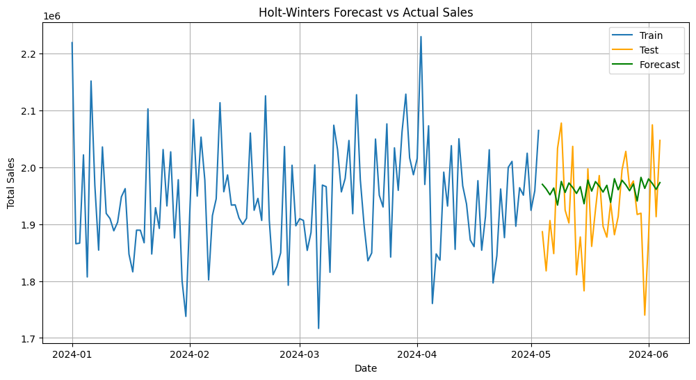

```python
from statsmodels.tsa.holtwinters import ExponentialSmoothing
import matplotlib.pyplot as plt

# Assuming 'train' and 'test' are already defined from your previous step

# Train the Holt-Winters model (additive trend and seasonality for daily data with weekly seasonality)
model = ExponentialSmoothing(
    train['Total Sales'],
    trend='add',
    seasonal='add',
    seasonal_periods=7
).fit()

# Forecast the same number of periods as the length of the test set
forecast = model.forecast(len(test))

# Plot actual vs predicted
plt.figure(figsize=(12, 6))
plt.plot(train.index, train['Total Sales'], label='Train')
plt.plot(test.index, test['Total Sales'], label='Test', color='orange')
plt.plot(test.index, forecast, label='Forecast', color='green')
plt.title('Holt-Winters Forecast vs Actual Sales')
plt.xlabel('Date')
plt.ylabel('Total Sales')
plt.legend()
plt.grid(True)
plt.show()
```

```python
from sklearn.metrics import mean_squared_error, mean_absolute_percentage_error
import numpy as np

# Ensure forecast and test are aligned
rmse = np.sqrt(mean_squared_error(test['Total Sales'], forecast))
mape = mean_absolute_percentage_error(test['Total Sales'], forecast) * 100  # in percentage

print(f"RMSE: {rmse:.2f}")
print(f"MAPE: {mape:.2f}%")
```

```
RMSE: 88224.43
MAPE: 3.89%
```

```
10:21:06 - cmdstanpy - INFO - Chain [1] start processing
10:21:14 - cmdstanpy - INFO - Chain [1] done processing
```

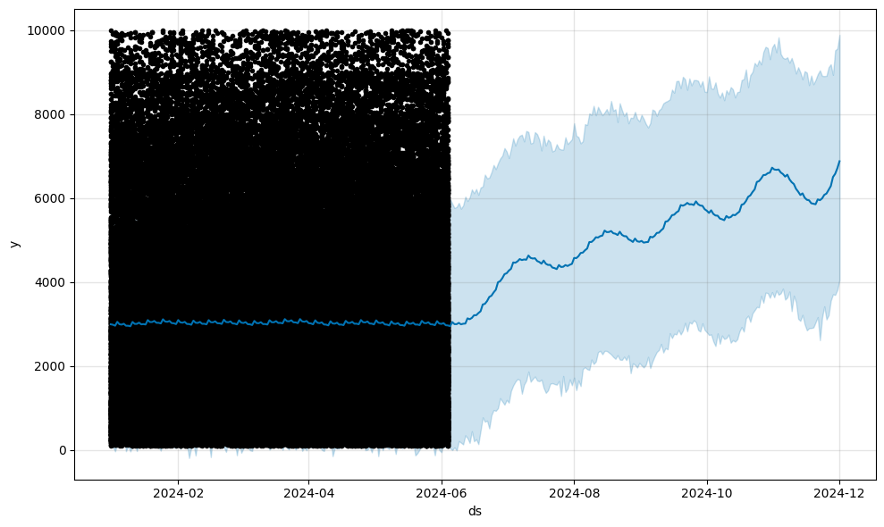

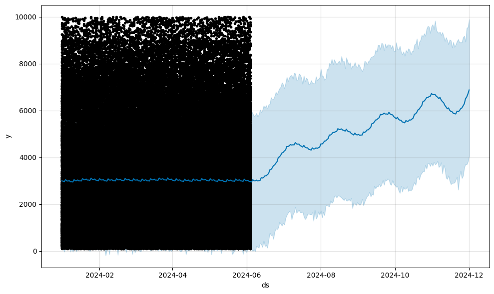

```python
from prophet import Prophet
import pandas as pd

# Prepare your data with columns: 'ds' (date) and 'y' (sales)
df_prophet = df.rename(columns={'Purchase Date': 'ds', 'Total Sales': 'y'})
df_prophet['ds'] = pd.to_datetime(df_prophet['ds'])

# Initialize model with seasonalities
model = Prophet(yearly_seasonality=True, daily_seasonality=False)
model.add_seasonality(name='diwali', period=365, fourier_order=10)  # Custom seasonality
model.fit(df_prophet)

# Create future dataframe (e.g., 180 days ahead)
future = model.make_future_dataframe(periods=180)
forecast = model.predict(future)

# Plot the forecast
model.plot(forecast)
```

```python
from statsmodels.tsa.holtwinters import ExponentialSmoothing

# Set date as index
df_hw = df.set_index('Purchase Date')
df_hw.index = pd.to_datetime(df_hw.index)
train_len = int(len(df_hw) * 0.8)
train, test = df_hw.iloc[:train_len], df_hw.iloc[train_len:]

# Train Holt-Winters model (additive seasonality assumed)
model = ExponentialSmoothing(train['Total Sales'], seasonal='add', seasonal_periods=12)
fit = model.fit()

# Predict next 6 to 12 months
forecast = fit.forecast(steps=len(test))
```

Include festive effects (like Diwali or Year-End Sales) via seasonal components.